# **Cyclistic BikeShare data reveal bussiness opportunities**

Compute the descriptive statistics from 2013 to 2023 by weekdays

```r
tri_rd_wday <- data.frame(
  weekday = c(rep("Mon", 2), rep("Tue", 2), rep("Wed", 2), rep("Thu", 2), rep("Fri", 2), rep("Sat", 2), rep("Sun", 2)),
  membership = c("Subscriber", "Customer"),
  max_distance = c(round(max(ride_data$rdistance[ride_data$membership == "Subscriber" & ride_data$start_day == "Mon" & ride_data$rdistance != 0]), digits = 2),
                   round(max(ride_data$rdistance[ride_data$membership == "Customer" & ride_data$start_day == "Mon" & ride_data$rdistance != 0]), digits = 2),
                   round(max(ride_data$rdistance[ride_data$membership == "Subscriber" & ride_data$start_day == "Tue" & ride_data$rdistance != 0]), digits = 2),
                   round(max(ride_data$rdistance[ride_data$membership == "Customer" & ride_data$start_day == "Tue" & ride_data$rdistance != 0]), digits = 2),
                   round(max(ride_data$rdistance[ride_data$membership == "Subscriber" & ride_data$start_day == "Wed" & ride_data$rdistance != 0]), digits = 2),
                   round(max(ride_data$rdistance[ride_data$membership == "Customer" & ride_data$start_day == "Wed" & ride_data$rdistance != 0]), digits = 2),
                   round(max(ride_data$rdistance[ride_data$membership == "Subscriber" & ride_data$start_day == "Thu" & ride_data$rdistance != 0]), digits = 2),
                   round(max(ride_data$rdistance[ride_data$membership == "Customer" & ride_data$start_day == "Thu" & ride_data$rdistance != 0]), digits = 2),
                   round(max(ride_data$rdistance[ride_data$membership == "Subscriber" & ride_data$start_day == "Fri" & ride_data$rdistance != 0]), digits = 2),
                   round(max(ride_data$rdistance[ride_data$membership == "Customer" & ride_data$start_day == "Fri" & ride_data$rdistance != 0]), digits = 2),
                   round(max(ride_data$rdistance[ride_data$membership == "Subscriber" & ride_data$start_day == "Sat" & ride_data$rdistance != 0]), digits = 2),
                   round(max(ride_data$rdistance[ride_data$membership == "Customer" & ride_data$start_day == "Sat" & ride_data$rdistance != 0]), digits = 2),
                   round(max(ride_data$rdistance[ride_data$membership == "Subscriber" & ride_data$start_day == "Sun" & ride_data$rdistance != 0]), digits = 2),
                   round(max(ride_data$rdistance[ride_data$membership == "Customer" & ride_data$start_day == "Sun" & ride_data$rdistance != 0]), digits = 2)),

  min_distance = c(round(min(ride_data$rdistance[ride_data$membership == "Subscriber" & ride_data$start_day == "Mon" & ride_data$rdistance != 0]), digits = 2),
                   round(min(ride_data$rdistance[ride_data$membership == "Customer" & ride_data$start_day == "Mon" & ride_data$rdistance != 0]), digits = 2),
                   round(min(ride_data$rdistance[ride_data$membership == "Subscriber" & ride_data$start_day == "Tue" & ride_data$rdistance != 0]), digits = 2),
                   round(min(ride_data$rdistance[ride_data$membership == "Customer" & ride_data$start_day == "Tue" & ride_data$rdistance != 0]), digits = 2),
                   round(min(ride_data$rdistance[ride_data$membership == "Subscriber" & ride_data$start_day == "Wed" & ride_data$rdistance != 0]), digits = 2),
                   round(min(ride_data$rdistance[ride_data$membership == "Customer" & ride_data$start_day == "Wed" & ride_data$rdistance != 0]), digits = 2),
                   round(min(ride_data$rdistance[ride_data$membership == "Subscriber" & ride_data$start_day == "Thu" & ride_data$rdistance != 0]), digits = 2),
                   round(min(ride_data$rdistance[ride_data$membership == "Customer" & ride_data$start_day == "Thu" & ride_data$rdistance != 0]), digits = 2),
                   round(min(ride_data$rdistance[ride_data$membership == "Subscriber" & ride_data$start_day == "Fri" & ride_data$rdistance != 0]), digits = 2),
                   round(min(ride_data$rdistance[ride_data$membership == "Customer" & ride_data$start_day == "Fri" & ride_data$rdistance != 0]), digits = 2),
                   round(min(ride_data$rdistance[ride_data$membership == "Subscriber" & ride_data$start_day == "Sat" & ride_data$rdistance != 0]), digits = 2),
                   round(min(ride_data$rdistance[ride_data$membership == "Customer" & ride_data$start_day == "Sat" & ride_data$rdistance != 0]), digits = 2),
                   round(min(ride_data$rdistance[ride_data$membership == "Subscriber" & ride_data$start_day == "Sun" & ride_data$rdistance != 0]), digits = 2),
                   round(min(ride_data$rdistance[ride_data$membership == "Customer" & ride_data$start_day == "Sun" & ride_data$rdistance != 0]), digits = 2)),

  mean_distance = c(round(mean(ride_data$rdistance[ride_data$membership == "Subscriber" & ride_data$start_day == "Mon" & ride_data$rdistance != 0]), digits = 2),
                    round(mean(ride_data$rdistance[ride_data$membership == "Customer" & ride_data$start_day == "Mon" & ride_data$rdistance != 0]), digits = 2),
                    round(mean(ride_data$rdistance[ride_data$membership == "Subscriber" & ride_data$start_day == "Tue" & ride_data$rdistance != 0]), digits = 2),
                    round(mean(ride_data$rdistance[ride_data$membership == "Customer" & ride_data$start_day == "Tue" & ride_data$rdistance != 0]), digits = 2),
                    round(mean(ride_data$rdistance[ride_data$membership == "Subscriber" & ride_data$start_day == "Wed" & ride_data$rdistance != 0]), digits = 2),
                    round(mean(ride_data$rdistance[ride_data$membership == "Customer" & ride_data$start_day == "Wed" & ride_data$rdistance != 0]), digits = 2),
                    round(mean(ride_data$rdistance[ride_data$membership == "Subscriber" & ride_data$start_day == "Thu" & ride_data$rdistance != 0]), digits = 2),
                    round(mean(ride_data$rdistance[ride_data$membership == "Customer" & ride_data$start_day == "Thu" & ride_data$rdistance != 0]), digits = 2),
                    round(mean(ride_data$rdistance[ride_data$membership == "Subscriber" & ride_data$start_day == "Fri" & ride_data$rdistance != 0]), digits = 2),
                    round(mean(ride_data$rdistance[ride_data$membership == "Customer" & ride_data$start_day == "Fri" & ride_data$rdistance != 0]), digits = 2),
                    round(mean(ride_data$rdistance[ride_data$membership == "Subscriber" & ride_data$start_day == "Sat" & ride_data$rdistance != 0]), digits = 2),
                    round(mean(ride_data$rdistance[ride_data$membership == "Customer" & ride_data$start_day == "Sat" & ride_data$rdistance != 0]), digits = 2),
                    round(mean(ride_data$rdistance[ride_data$membership == "Subscriber" & ride_data$start_day == "Sun" & ride_data$rdistance != 0]), digits = 2),
                    round(mean(ride_data$rdistance[ride_data$membership == "Customer" & ride_data$start_day == "Sun" & ride_data$rdistance != 0]), digits = 2)),
```

[figure not shown]

```r
  median_distance = c(round(median(ride_data$rdistance[ride_data$membership == "Subscriber" & ride_data$start_day == "Mon" & ride_data$rdistance != 0]), digits = 2),
                      round(median(ride_data$rdistance[ride_data$membership == "Customer" & ride_data$start_day == "Mon" & ride_data$rdistance != 0]), digits = 2),
                      round(median(ride_data$rdistance[ride_data$membership == "Subscriber" & ride_data$start_day == "Tue" & ride_data$rdistance != 0]), digits = 2),
                      round(median(ride_data$rdistance[ride_data$membership == "Customer" & ride_data$start_day == "Tue" & ride_data$rdistance != 0]), digits = 2),
                      round(median(ride_data$rdistance[ride_data$membership == "Subscriber" & ride_data$start_day == "Wed" & ride_data$rdistance != 0]), digits = 2),
                      round(median(ride_data$rdistance[ride_data$membership == "Customer" & ride_data$start_day == "Wed" & ride_data$rdistance != 0]), digits = 2),
                      round(median(ride_data$rdistance[ride_data$membership == "Subscriber" & ride_data$start_day == "Thu" & ride_data$rdistance != 0]), digits = 2),
                      round(median(ride_data$rdistance[ride_data$membership == "Customer" & ride_data$start_day == "Thu" & ride_data$rdistance != 0]), digits = 2),
                      round(median(ride_data$rdistance[ride_data$membership == "Subscriber" & ride_data$start_day == "Fri" & ride_data$rdistance != 0]), digits = 2),
                      round(median(ride_data$rdistance[ride_data$membership == "Customer" & ride_data$start_day == "Fri" & ride_data$rdistance != 0]), digits = 2),
                      round(median(ride_data$rdistance[ride_data$membership == "Subscriber" & ride_data$start_day == "Sat" & ride_data$rdistance != 0]), digits = 2),
                      round(median(ride_data$rdistance[ride_data$membership == "Customer" & ride_data$start_day == "Sat" & ride_data$rdistance != 0]), digits = 2),
                      round(median(ride_data$rdistance[ride_data$membership == "Subscriber" & ride_data$start_day == "Sun" & ride_data$rdistance != 0]), digits = 2),
                      round(median(ride_data$rdistance[ride_data$membership == "Customer" & ride_data$start_day == "Sun" & ride_data$rdistance != 0]), digits = 2)),

  standard_deviantion = c(sd(ride_data$rdistance[ride_data$membership == "Subscriber" & ride_data$start_day == "Mon" & ride_data$rdistance != 0]),
                          sd(ride_data$rdistance[ride_data$membership == "Customer" & ride_data$start_day == "Mon" & ride_data$rdistance != 0]),
                          sd(ride_data$rdistance[ride_data$membership == "Subscriber" & ride_data$start_day == "Tue" & ride_data$rdistance != 0]),
                          sd(ride_data$rdistance[ride_data$membership == "Customer" & ride_data$start_day == "Tue" & ride_data$rdistance != 0]),
                          sd(ride_data$rdistance[ride_data$membership == "Subscriber" & ride_data$start_day == "Wed" & ride_data$rdistance != 0]),
                          sd(ride_data$rdistance[ride_data$membership == "Customer" & ride_data$start_day == "Wed" & ride_data$rdistance != 0]),
                          sd(ride_data$rdistance[ride_data$membership == "Subscriber" & ride_data$start_day == "Thu" & ride_data$rdistance != 0]),
                          sd(ride_data$rdistance[ride_data$membership == "Customer" & ride_data$start_day == "Thu" & ride_data$rdistance != 0]),
                          sd(ride_data$rdistance[ride_data$membership == "Subscriber" & ride_data$start_day == "Fri" & ride_data$rdistance != 0]),
                          sd(ride_data$rdistance[ride_data$membership == "Customer" & ride_data$start_day == "Fri" & ride_data$rdistance != 0]),
                          sd(ride_data$rdistance[ride_data$membership == "Subscriber" & ride_data$start_day == "Sat" & ride_data$rdistance != 0]),
                          sd(ride_data$rdistance[ride_data$membership == "Customer" & ride_data$start_day == "Sat" & ride_data$rdistance != 0]),
                          sd(ride_data$rdistance[ride_data$membership == "Subscriber" & ride_data$start_day == "Sun" & ride_data$rdistance != 0]),
                          sd(ride_data$rdistance[ride_data$membership == "Customer" & ride_data$start_day == "Sun" & ride_data$rdistance != 0]))
)
kable(tri_rd_wday, style = "rmarkdown")

# visualise
# create a box plot.
p_tri_rd_wday_box <- ggplot(ride_data, aes(x =  factor(start_day,
                                                       level = c("Mon", "Tue", "Wed", "Thu", "Fri", "Sat", "Sun")),
                                           y = rdistance, colour = membership, fill = membership)) +
  geom_boxplot(stat = "boxplot", alpha = 0.3) +
  scale_y_continuous(limits = quantile(ride_data$rdistance, c(0.1, 0.9))) +
  xlab("Weekdays") +
  ylab("Ride Distance") +
  ggtitle("Ride Distance by Subscribers and Customers (daily Monday - Friday)") +
  scale_colour_manual(name = "membership", values = c("#41B6E6", "#E4002B")) +
  scale_fill_manual(name = "membership", values = c("#41B6E6", "#E4002B")) +
  theme_classic() +
  theme(plot.title = element_text(hjust = 0.5))
p_tri_rd_wday_box
```

[figure not shown]

```r
invisible(gc())
# subscribers consistently have shorter mean ride distance than customers.

# scatter points to visualise the entire data set.
ride_data$membership <- as.factor(ride_data$membership)
p_tri_rd_point_wday <- ggplot(ride_data, aes(x =  start_day, y = rdistance, colour = membership)) +
  geom_jitter() +
  scale_y_continuous(labels = unit_format(unit = "km", scale = 1e-3), expand = c(0, 0), limits = c(0, NA)) +
  xlab("Weekdays") +
  ylab("Ride Distance") +
  ggtitle("Ride Distance by Subscribers and Customers (daily Monday - Friday)") +
  scale_colour_manual(name = "membership", values = c("#41B6E6", "#E4002B")) +
  theme_classic() +
  theme(plot.title = element_text(hjust = 0.5))
p_tri_rd_point_wday
```

[figure not shown]

```r
invisible(gc())

# create a line plot to see fluctuation of means during a given week explicitly.
p_tri_rd_line_wday <- ggplot(data = tri_rd_wday) +
  geom_line(aes(x = factor(weekday,
                           level = c("Mon", "Tue", "Wed", "Thu", "Fri", "Sat", "Sun")),
                y = mean_distance, group = membership, color = membership)) +
  geom_line(linetype = "dashed", aes(x = factor(weekday,
                                                level = c("Mon", "Tue", "Wed", "Thu", "Fri", "Sat", "Sun")),
                                     y = median_distance, group = membership, color = membership)) +
  xlab("Weekdays") +
  ylab("Ride Distance") +
  ggtitle("Ride Distance by Subscribers and Customers (daily Monday - Friday)") +
  scale_colour_manual(name = "membership", values = c("#41B6E6", "#E4002B")) +
  scale_y_continuous(labels = unit_format(unit = "KM", scale = 1e-3), expand = c(0, 0), limits = c(0, NA)) +
  theme_classic() +
  theme(plot.title = element_text(hjust = 0.5))
p_tri_rd_line_wday
```

```r
invisible(gc())
```

[output not shown]

Result of this section: (1) subscribers consistently have shorter mean ride distance than customers.

Using statistic tests to examine whether the observed differences among the weekdays are significant.

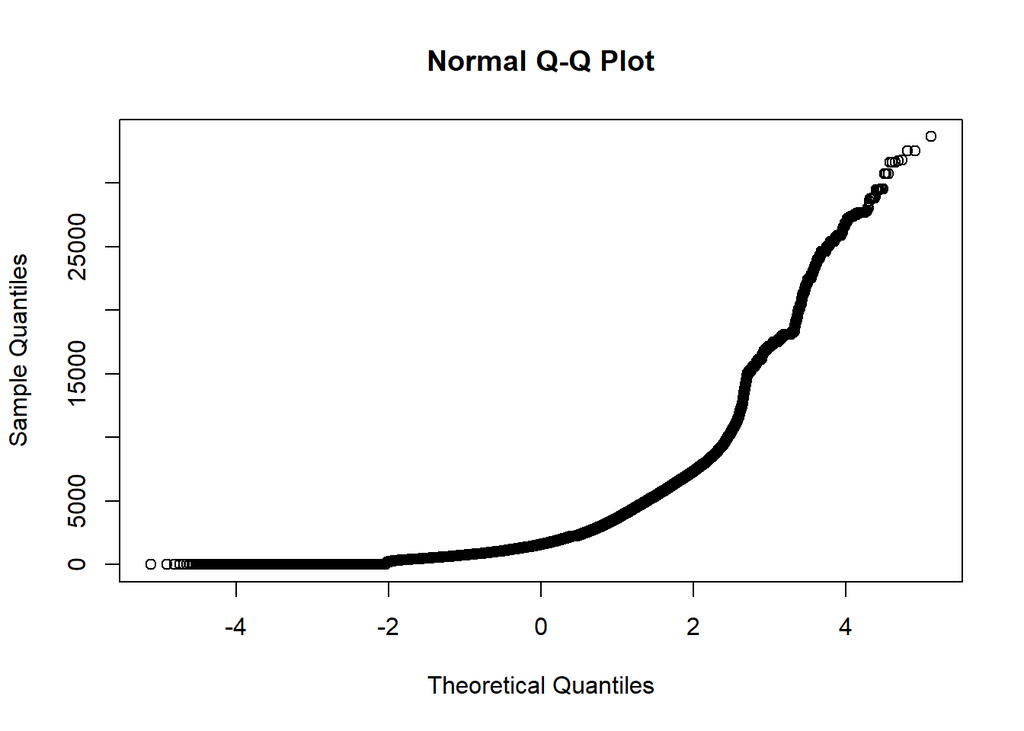

```r
# perform statistic tests check for normality
qqnorm(ride_data$rdistance[ride_data$membership == "Subscriber" & ride_data$start_day ==
    "Mon"])
```

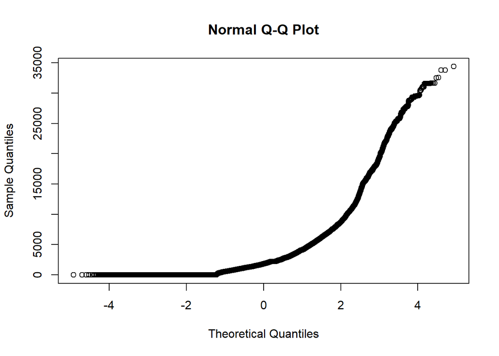

```r
# not normal
qqnorm(ride_data$rdistance[ride_data$membership == "Customer" & ride_data$start_day ==
    "Mon"])
```

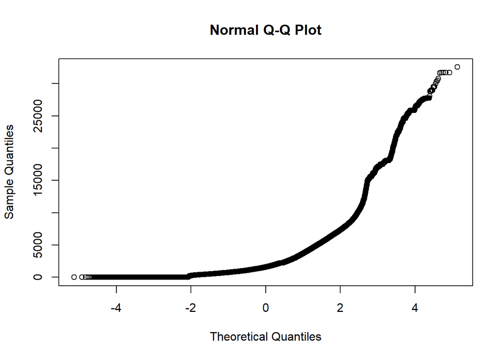

```r
# not normal
qqnorm(ride_data$rdistance[ride_data$membership == "Subscriber" & ride_data$start_day ==
    "Tue"])
```

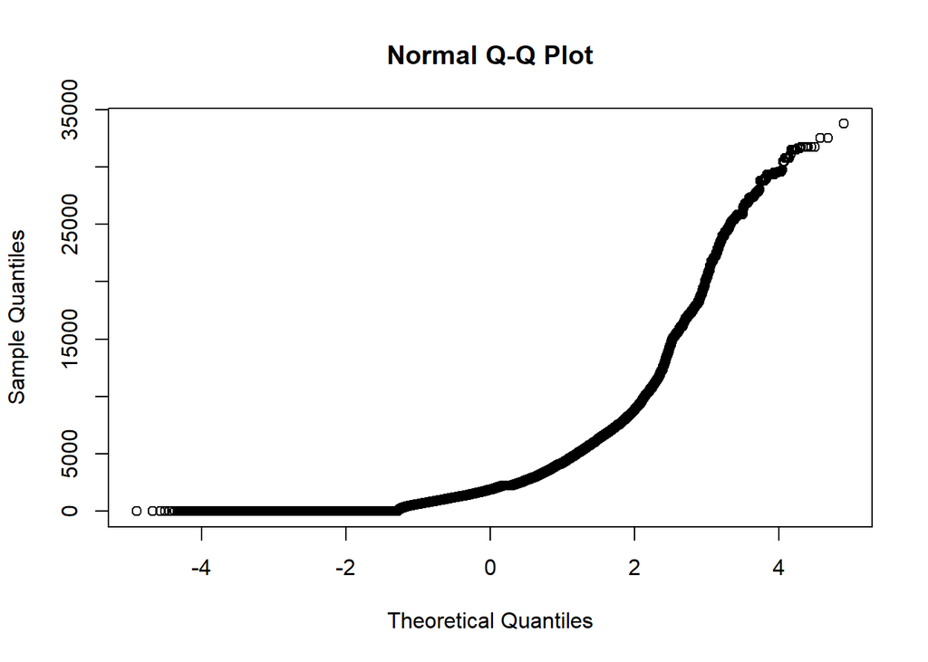

```r
# not normal
qqnorm(ride_data$rdistance[ride_data$membership == "Customer" & ride_data$start_day ==
    "Tue"])
```

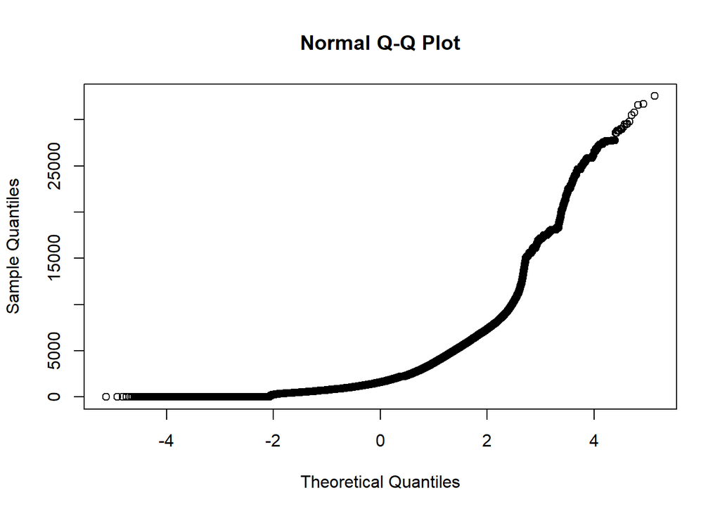

```r
# not normal
qqnorm(ride_data$rdistance[ride_data$membership == "Subscriber" & ride_data$start_day ==
    "Wed"])
```

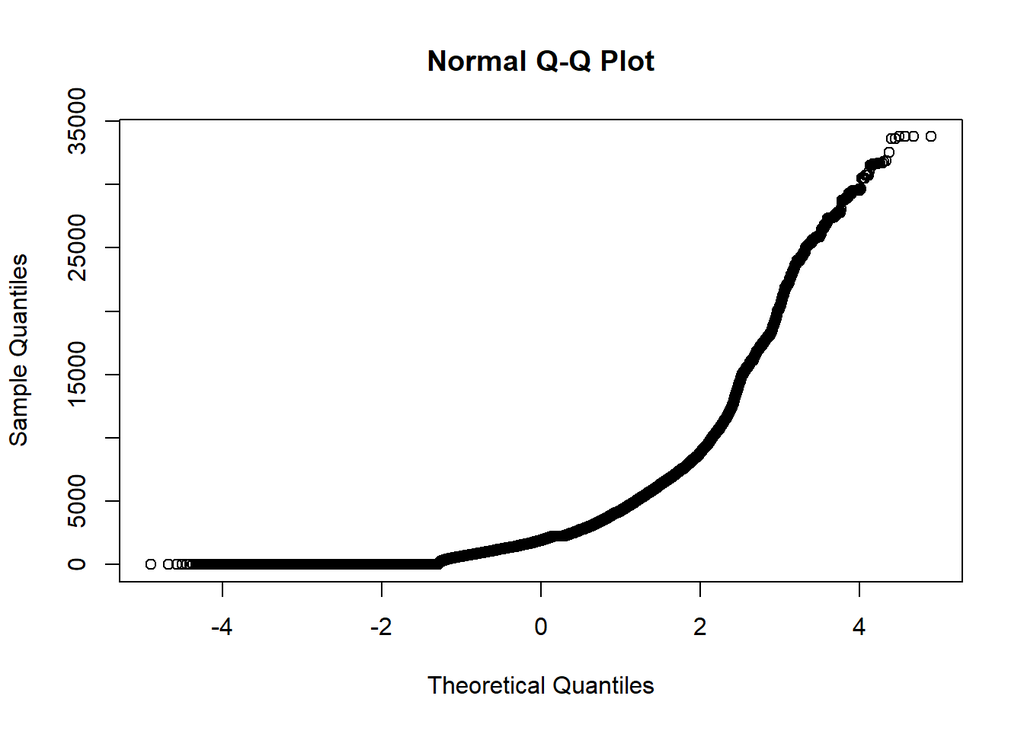

```r
# not normal
qqnorm(ride_data$rdistance[ride_data$membership == "Customer" & ride_data$start_day ==
    "Wed"])
```

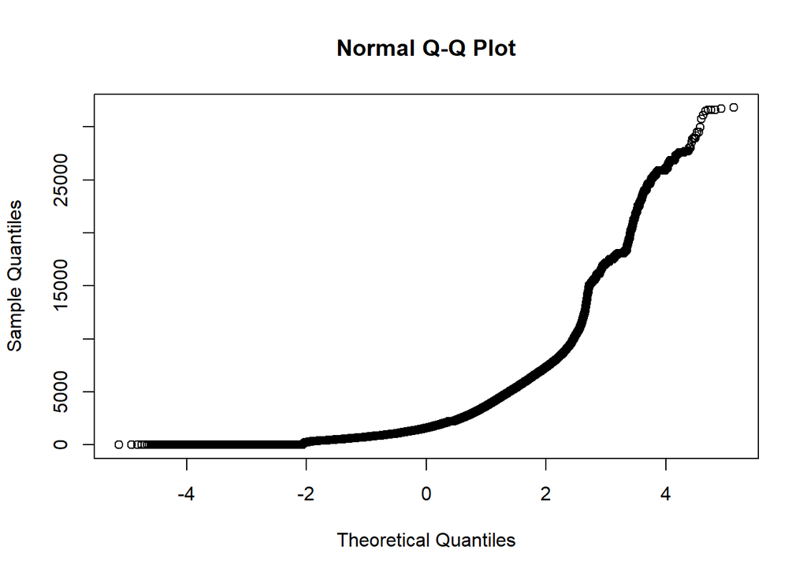

```r
# not normal
qqnorm(ride_data$rdistance[ride_data$membership == "Subscriber" & ride_data$start_day ==
    "Thu"])
```

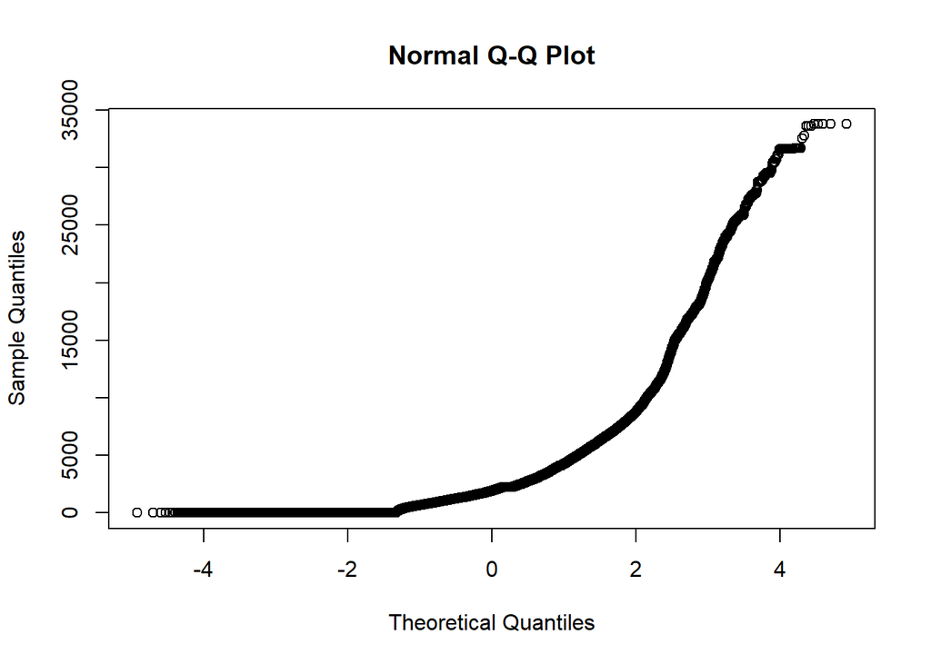

```r
# not normal
qqnorm(ride_data$rdistance[ride_data$membership == "Customer" & ride_data$start_day ==
    "Thu"])
```

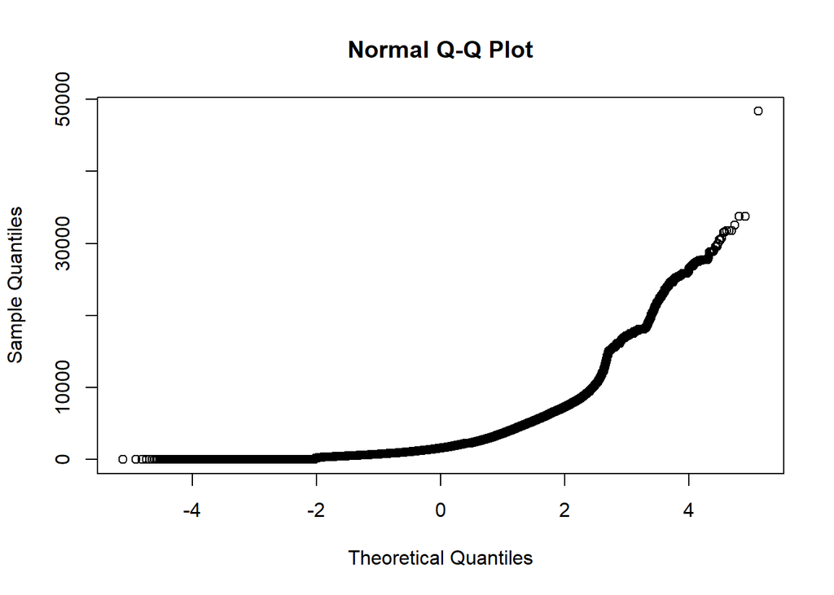

```r
# not normal
qqnorm(ride_data$rdistance[ride_data$membership == "Subscriber" & ride_data$start_day ==
    "Fri"])
```

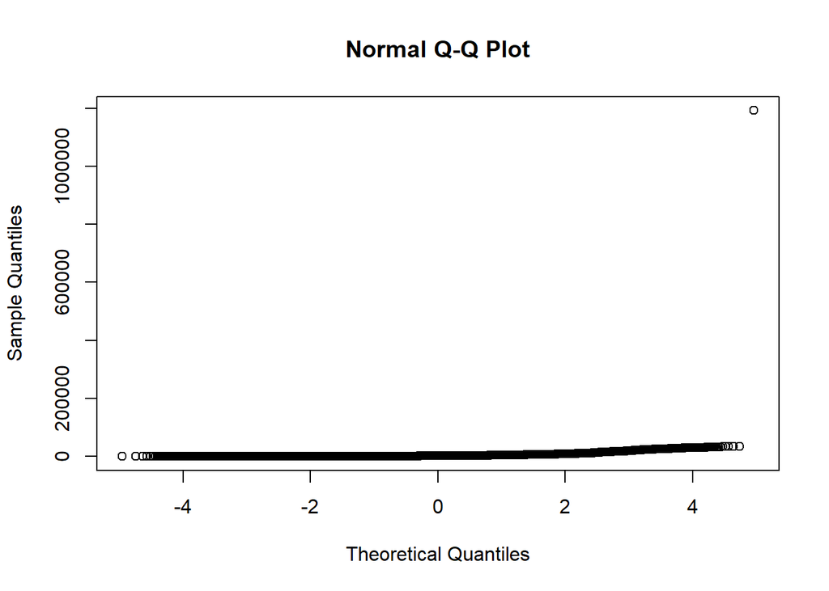

```r
# not normal
qqnorm(ride_data$rdistance[ride_data$membership == "Customer" & ride_data$start_day ==
    "Fri"])
```

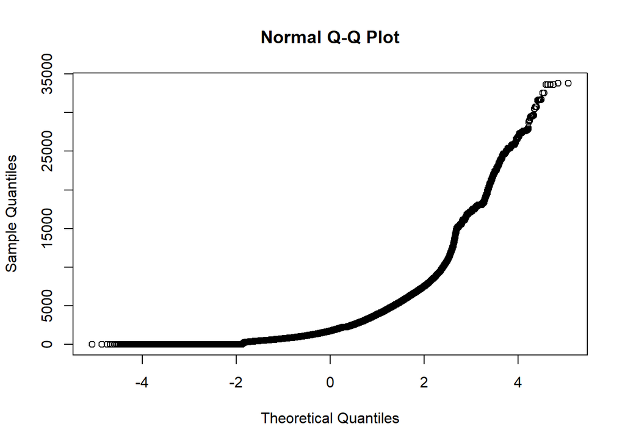

```r
# not normal
qqnorm(ride_data$rdistance[ride_data$membership == "Subscriber" & ride_data$start_day ==
    "Sat"])
```

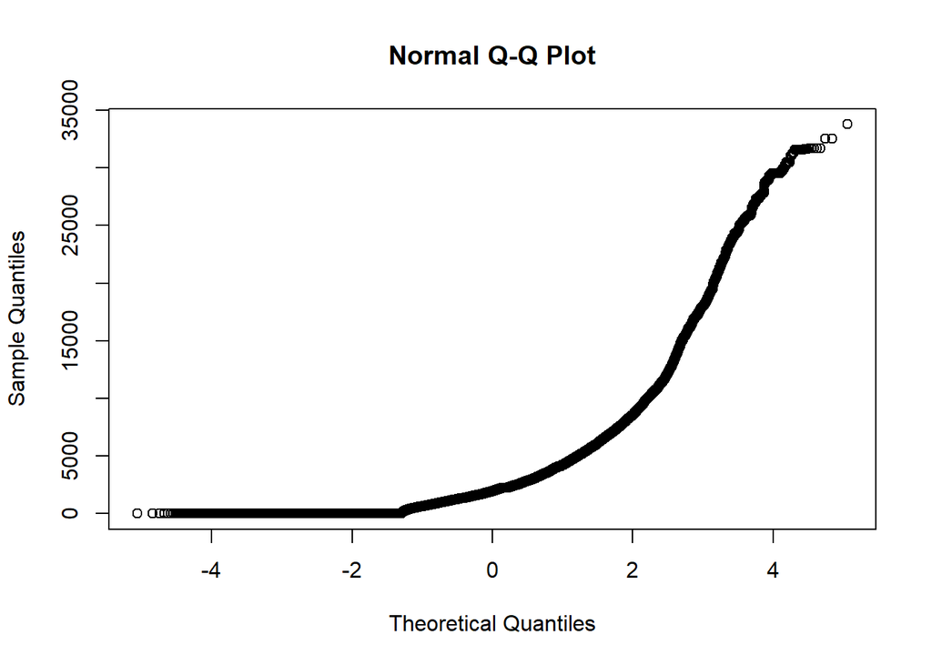

```r
# not normal
qqnorm(ride_data$rdistance[ride_data$membership == "Customer" & ride_data$start_day ==
    "Sat"])
```

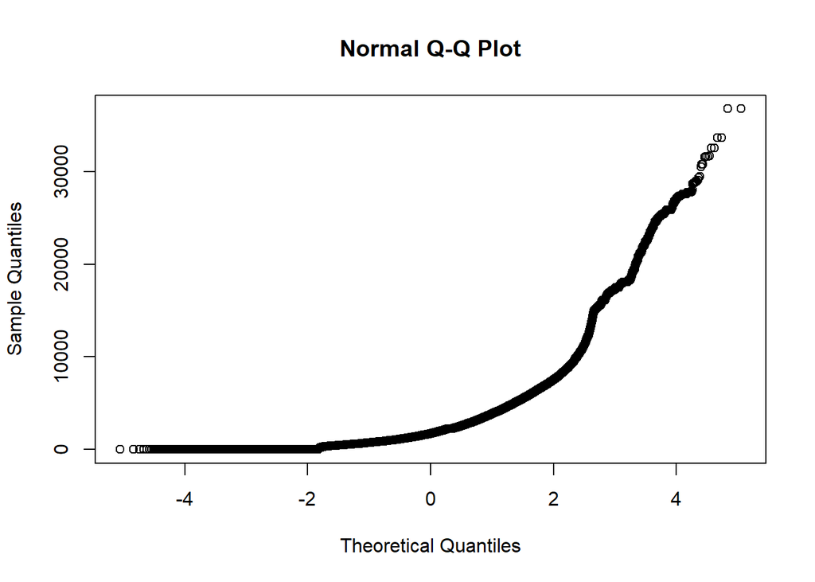

```r
# not normal
qqnorm(ride_data$rdistance[ride_data$membership == "Subscriber" & ride_data$start_day ==
    "Sun"])
```

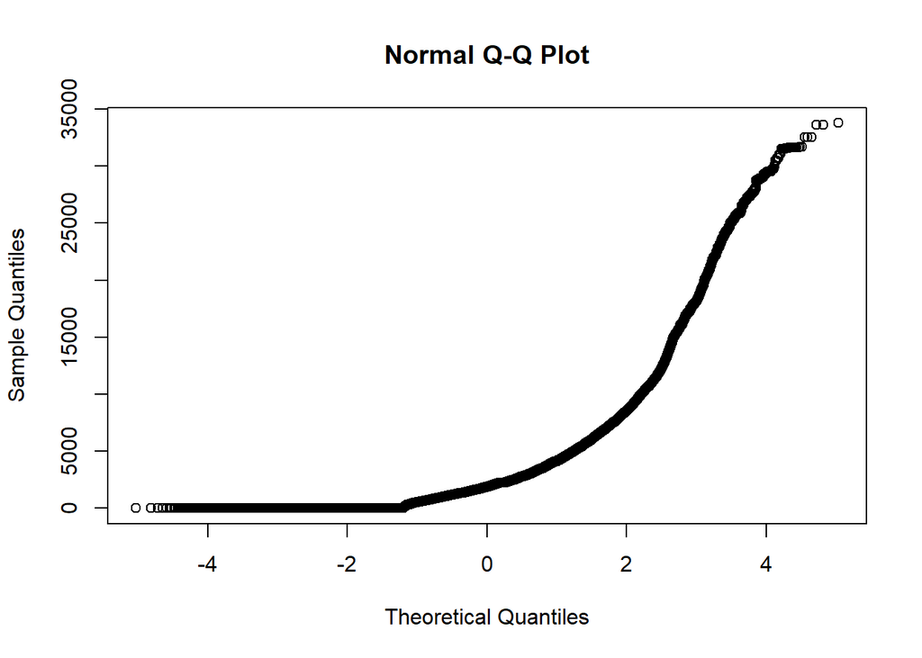

```r
# not normal
qqnorm(ride_data$rdistance[ride_data$membership == "Customer" & ride_data$start_day ==
    "Sun"])
```

```r
# not normal

# as the data is not normally distributed, we can use a non-parametric ANOVA to
# test whether the observed difference is statistically significant.
kruskal_sub_result <- kruskal.test(data = ride_data[ride_data$membership == "Subscriber",
    ], rdistance ~ start_day)
kruskal_sub_result
# p-value < 2.2e-16, and the difference among years are significant!

# let's follow up with a pairwise comparison to find out between which
# weekdays, the difference is significant.  we can achieve this with Wilcoxon
# signed ranking test for subscribers.
wsr_sub_data <- ride_data[ride_data$membership == "Subscriber", ] %>%
    select(start_day, rdistance)
wsr_sub_data$start_year <- as.factor(wsr_sub_data$start_day)
wsr_sub_result <- dunn_test(data = wsr_sub_data, rdistance ~ start_day, p.adjust.method = "bonferroni")
wsr_sub_result
# for subscribers, ride distance is significantly different between weekdays,
# except for between Tuesday and Wednesday, and between Tuesday and Thursday.

# for customers.
kruskal_cus_result <- kruskal.test(data = ride_data[ride_data$membership == "Customer",
    ], rdistance ~ start_day)
kruskal_cus_result
# p-value < 2.2e-16, and the difference among years are significant!

# let's follow up with a pairwise comparison to find out between which
# weekdays, the difference is significant.  we can achieve this with Wilcoxon
# signed ranking test
wsr_cus_data <- ride_data[ride_data$membership == "Customer", ] %>%
    select(start_day, rdistance)
wsr_cus_data$start_year <- as.factor(wsr_cus_data$start_day)
wsr_cus_result <- dunn_test(data = wsr_cus_data, rdistance ~ start_day, p.adjust.method = "bonferroni")
wsr_cus_result
# for customers, ride distance is significantly different between weekdays,
# except for the days among Wednesday through Friday.
invisible(gc())
```

```
##
##  Kruskal-Wallis rank sum test
##
## data:  rdistance by start_day
## Kruskal-Wallis chi-squared = 18060, df = 6, p-value < 2.2e-16
##
## # A tibble: 21 × 9
##    .y.      group1 group2     n1     n2 statistic        p    p.adj p.adj.signif
##  * <chr>    <chr>  <chr>   <int>  <int>     <dbl>    <dbl>    <dbl> <chr>
##  1 rdistan… Sun    Mon    2.29e6 3.23e6    -73.6  0        0        ****
##  2 rdistan… Sun    Tue    2.29e6 3.55e6    -66.4  0        0        ****
##  3 rdistan… Sun    Wed    2.29e6 3.53e6    -63.3  0        0        ****
##  4 rdistan… Sun    Thu    2.29e6 3.48e6    -67.5  0        0        ****
##  5 rdistan… Sun    Fri    2.29e6 3.28e6    -78.6  0        0        ****
##  6 rdistan… Sun    Sat    2.29e6 2.55e6     17.2  6.19e-66 1.30e-64 ****
##  7 rdistan… Mon    Tue    3.23e6 3.55e6      9.45 3.51e-21 7.38e-20 ****
##  8 rdistan… Mon    Wed    3.23e6 3.53e6     12.8  1.22e-37 2.57e-36 ****
##  9 rdistan… Mon    Thu    3.23e6 3.48e6      7.95 1.82e-15 3.83e-14 ****
## 10 rdistan… Mon    Fri    3.23e6 3.28e6     -5.18 2.22e- 7 4.65e- 6 ****
## # ℹ 11 more rows
##
##  Kruskal-Wallis rank sum test
##
## data:  rdistance by start_day
## Kruskal-Wallis chi-squared = 4993.7, df = 6, p-value < 2.2e-16
##
## # A tibble: 21 × 9
##    .y.    group1 group2     n1     n2 statistic         p     p.adj p.adj.signif
##  * <chr>  <chr>  <chr>   <int>  <int>     <dbl>     <dbl>     <dbl> <chr>
##  1 rdist… Sun    Mon    2.07e6 1.20e6     -16.7 1.39e- 62 2.92e- 61 ****
##  2 rdist… Sun    Tue    2.07e6 1.06e6      11.7 7.14e- 32 1.50e- 30 ****
##  3 rdist… Sun    Wed    2.07e6 1.06e6      23.2 2.41e-119 5.07e-118 ****
##  4 rdist… Sun    Thu    2.07e6 1.15e6      28.5 1.76e-178 3.70e-177 ****
##  5 rdist… Sun    Fri    2.07e6 1.41e6      29.9 9.74e-197 2.05e-195 ****
##  6 rdist… Sun    Sat    2.07e6 2.39e6      50.1 0         0         ****
##  7 rdist… Mon    Tue    1.20e6 1.06e6      24.9 5.52e-137 1.16e-135 ****
##  8 rdist… Mon    Wed    1.20e6 1.06e6      35.2 1.68e-271 3.53e-270 ****
##  9 rdist… Mon    Thu    1.20e6 1.15e6      40.1 0         0         ****
## 10 rdist… Mon    Fri    1.20e6 1.41e6      41.8 0         0         ****
## # ℹ 11 more rows
```

Result of this section: (1) for subscribers, ride distance is significantly different from Friday to Monday, but the ride distance is comparable from Tuesday through Thursday. (2) for customers, ride distance is significantly different for a given weekday except for those among Wednesday through Friday. (3) both subscribers and customers have comparable ride distance on Wednesday and Thursday within the same membership category.

### 5.4.5 Geographic location as a primary metric

Examine the geospatial distribution of where rides start and end

[figure not shown]

```r
# What are the geographic distributions of subscribers and customers in
# Chicago?  convert dataframe numbers to GPS format
start_map <- ride_data[, c(8:10)]
start_map <- st_as_sf(start_map, coords = c("start_station_lon", "start_station_lat"))
start_map$membership <- as.factor(start_map$membership)
end_map <- ride_data[, c(8, 14, 15)]
end_map <- st_as_sf(end_map, coords = c("end_station_lon", "end_station_lat"))
end_map$membership <- as.factor(end_map$membership)

# remove the unused object to save RAM
invisible(gc())

# I have limited RAM on my computer so I need to transform and simplify the
# dataset data from 2013 to 2023 are compiled into one, and only the distinct
# rows are preserved the number of duplicate rows are counted and used as a
# scaling factor for start station
start_map <- start_map %>%
    group_by_all() %>%
    count
start_map$n <- (start_map$n)
colnames(start_map) <- c("membership", "geometry", "Number of Ride")
invisible(gc())

start_map_plot <- tm_shape(shp = chicago) + tm_polygons(col = "#FFFAD7") + tm_shape(start_map) +
    tm_bubbles(col = "membership", palette = c("#41B6E6", "#E4002B"), jitter = 0.01,
        size = "Number of Ride") + tm_layout(legend.outside = TRUE) + tm_layout(legend.position = c("right",
    "bottom"), title = "Locations of End Stations", title.position = c("right", "top"))
start_map_plot
```

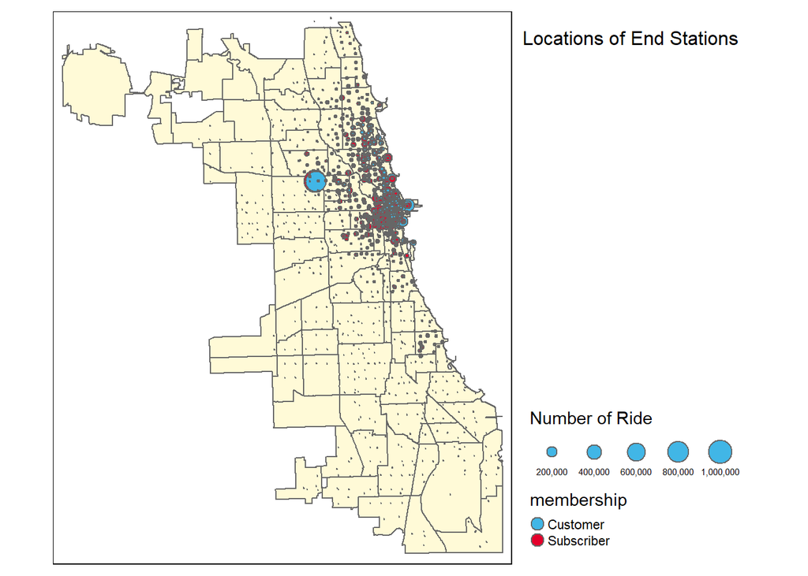

```r
invisible(gc())

end_map <- end_map %>%
    group_by_all() %>%
    count
end_map$n <- (end_map$n)
colnames(end_map) <- c("membership", "geometry", "Number of Ride")
invisible(gc())

# for end station
end_map_plot <- tm_shape(shp = chicago) + tm_polygons(col = "#FFFAD7") + tm_shape(end_map) +
    tm_bubbles(col = "membership", palette = c("#41B6E6", "#E4002B"), jitter = 0.01,
        size = "Number of Ride") + tm_layout(legend.outside = TRUE) + tm_layout(legend.position = c("right",
    "bottom"), title = "Locations of End Stations", title.position = c("right", "top"))
end_map_plot
```

```r
invisible(gc())
```

Result of this section: (1) rides most frequently start and end in the northeast section of Chicago. (2) Considering only the station with highest ride frequency, the end station is a bit south to its corresponding start station.

## 5.5 General conclusions

From our examination, exploration, and analyses of the data set, we can derive the following conclusions and recommendations:

### 5.5.1 Data integrity

1. Data loss occurred in 2017 and 2020. Highest numbers of data loss overlap the highest number of rides, which is not surprising. However, rides outside of Chicago proper are mostly if not exclusively found from the loss data portion of the data set. Accordingly, Cyclistic may want to limit their current services to Chicago proper to prevent further data loss, especially if those loss are associated with the loss of the physical bikes.
2. data collection evolves as the company grows, which is normal. It would, however, be nice to have consistent terminology for all collected data. If terminology needs to be revised, old data could preferably be updated as the new terminology is put to used.

### 5.5.2 rideing behaviours of subscribers and customers

1. the number of ride by subscribers are consistently higher than those by the customers when measured by the entire data set and annually. However, customers ride more often than subscribers on weekends. This suggests that subscribers may have been using the services of Cyclistic to commute to and from work.
2. subscribers prefers classic bikes whereas customers use electric bikes more. Continue collecting data on user preference may help facilitating service strategies for subscribers and customers in the future, respectively.
3. both trip duration and ride distance are generally shorter for subscribers compared to customers. This echoes the possibility that subscribers use services of Cyclistic to commute to and from work.
4. the difference in trip duration and ride distance between subscribers and customers is reduced since 2021, which may have been a result of impacts from the COVID-19 pandemic. To further explore the significance of this potential impact, it would be nice to collect/retrieve the number of subscribers and customers throughout the years, in order to examine whether the number of subscribers along with the conversion rate from customers to subscribers have changed.
5. most of the ride starts and ends in the northeast parts of Chicago close to the downtown area. The most active start station is only within two districts west to the downtown area of Chicago.